# Trilha3-Explorando a Base de Dados diamonds do pacote ggplot2

### Explore a variável x, seguindo o modelo de exploração.

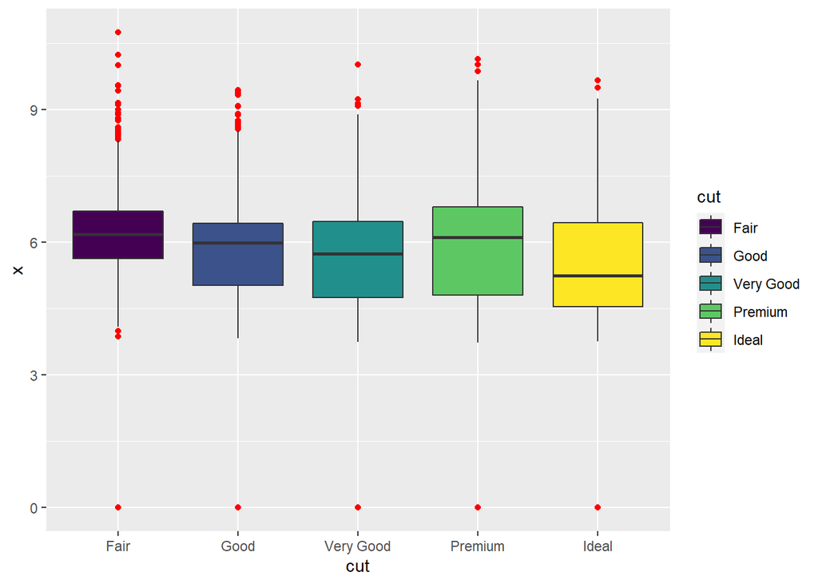

```r
ggplot(data = diamonds, mapping = aes(x = cut, y =x , fill =cut )) + geom_boxplot(outlier.color = "red")
```

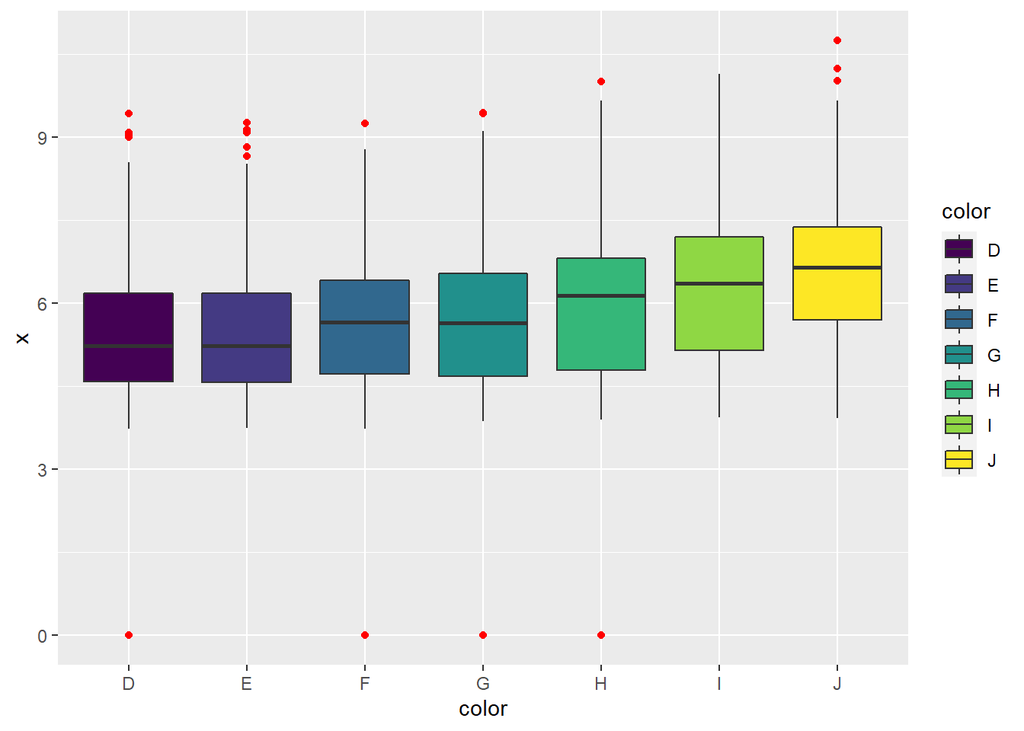

```r
ggplot(data = diamonds, mapping = aes(x = color, y =x , fill =color )) + geom_boxplot(outlier.color = "red")
```

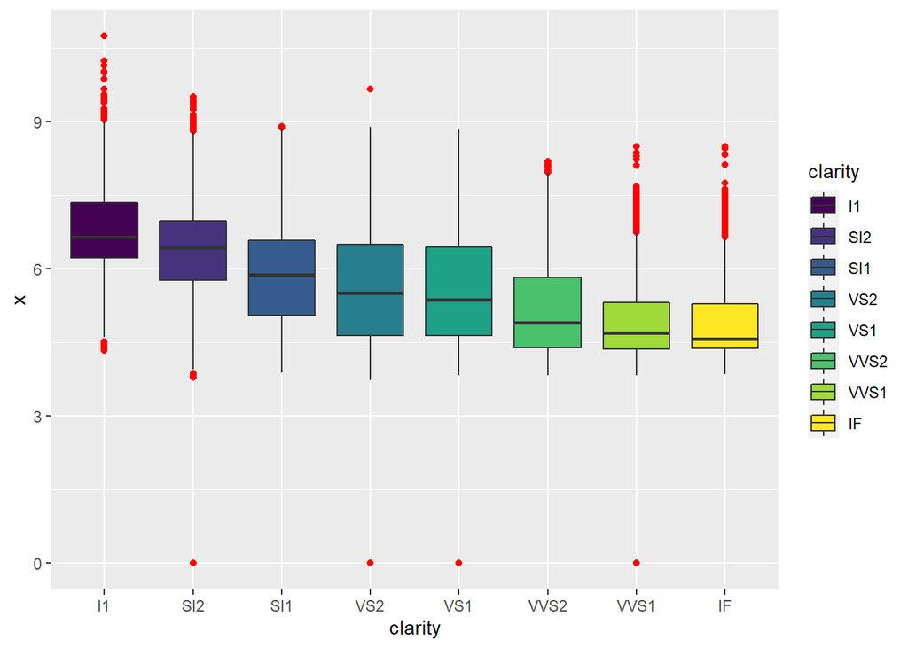

```r
ggplot(data = diamonds, mapping = aes(x = clarity, y =x , fill =clarity )) + geom_boxplot(outlier.color = "red")
```

### Análise: Acima fizemos a comparação do comprimento dos diamantes conforme a qualidade do corte, cor e claridade (transparencia do diamante). O tipo de corte que mais influencia o comprimento dos diamantes é o premium, embora as medianas sejam muito próximas. A qualidade de cor que mais influencia o comprimento dos diamantes é a cor J (pior cor),embora as medianas sejam muito próximas. A claridade (transparência) que mais influencia o comprimento dos diamantes é a I1, embora todas sejam muito parecidos em sua mediana.

### Explore a variável y, seguindo o modelo de exploração.

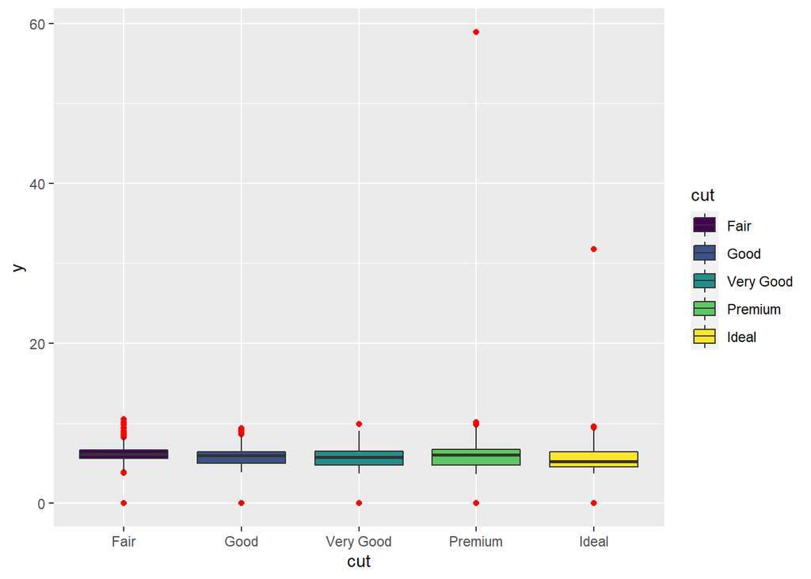

```r
ggplot(data = diamonds, mapping = aes(x = cut, y =y , fill =cut )) + geom_boxplot(outlier.color = "red")
```

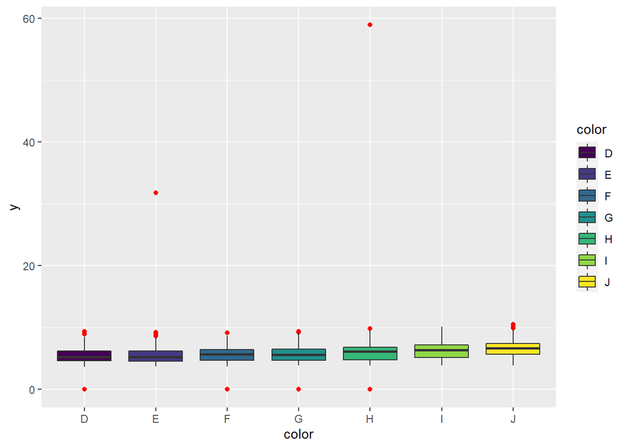

```r
ggplot(data = diamonds, mapping = aes(x = color, y =y , fill =color )) + geom_boxplot(outlier.color = "red")
```

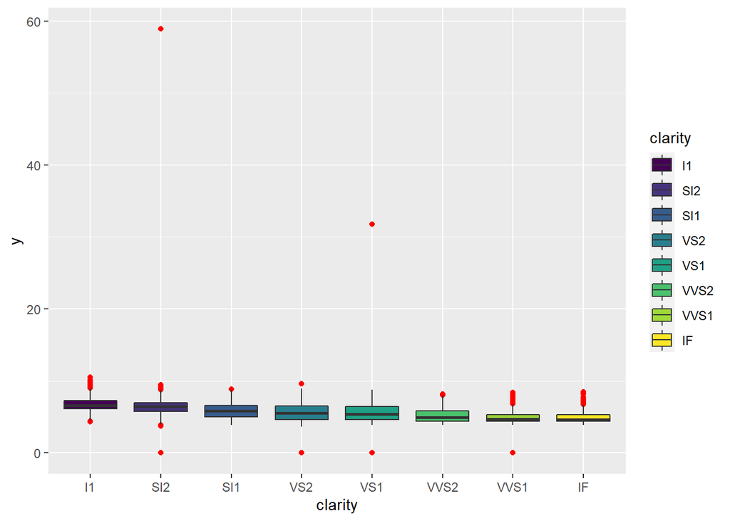

```r
ggplot(data = diamonds, mapping = aes(x = clarity, y =y , fill =clarity )) + geom_boxplot(outlier.color = "red")
```

### Análise: Acima fizemos a comparação da largura dos diamantes conforme a qualidade do corte, cor e claridade (transparencia do diamante). O tipo de corte que mais influencia a largura dos diamantes é o premium, embora as medianas sejam muito próximas. A qualidade de cor que mais influencia a largura dos diamantes é a cor J (pior cor),embora as medianas sejam muito próximas. A claridade (transparência) que mais influencia a largura dos diamantes é a I1, embora todas sejam muito parecidos em sua mediana.

## Gráfico de Barras

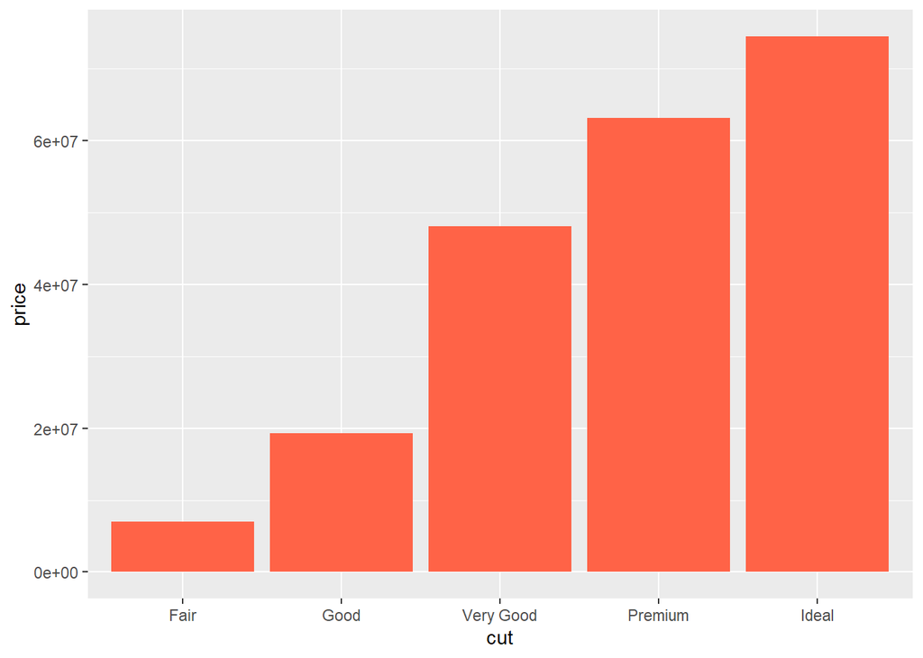

```r
ggplot(diamonds, aes(y = price, x = cut)) + geom_bar(stat = "identity", fill = "tomato")
```

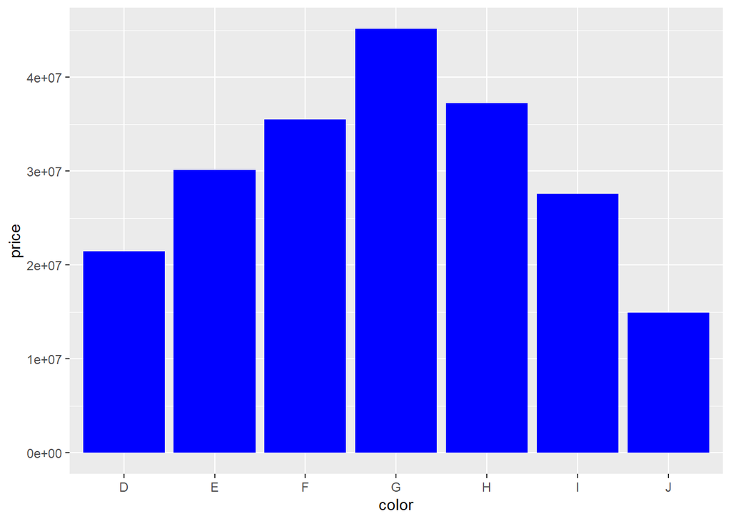

```r
ggplot(diamonds, aes(y = price, x = color)) + geom_bar(stat = "identity", fill = "blue")
```

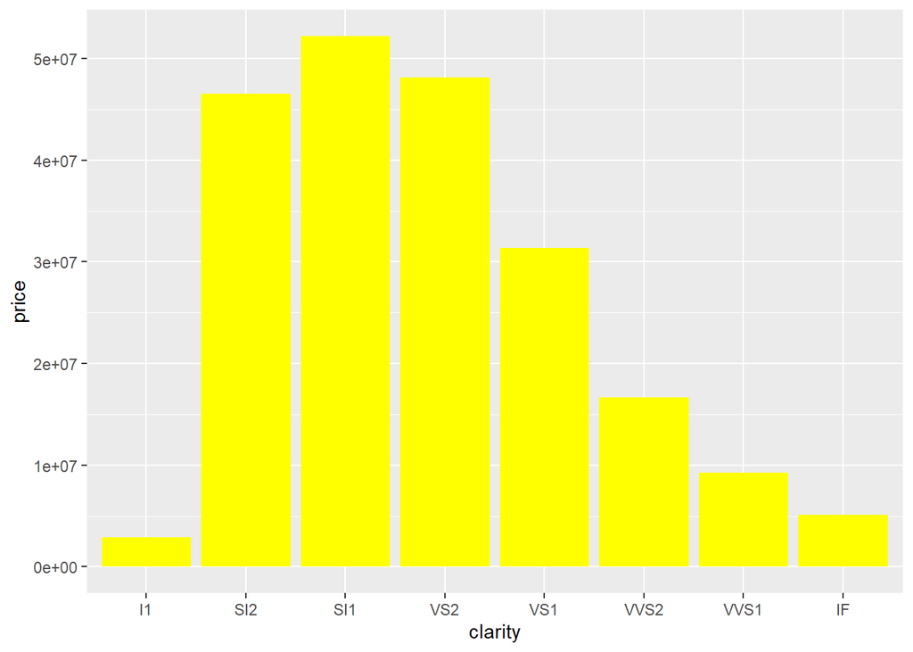

```r
ggplot(diamonds, aes(y = price, x = clarity)) + geom_bar(stat = "identity", fill = "yellow")
```

### Análise: Acima fizemos a comparação do preço dos diamantes conforme a qualidade do corte, cor e claridade (transparencia do diamante). O tipo de corte que mais influencia o preço dos diamantes é o Ideal. A qualidade de cor que mais influencia o preço dos diamantes é a cor G. A claridade (transparência) que mais influencia o preço dos diamantes é o SI1.

## Scatterplot (Gráfico de Dispersao)

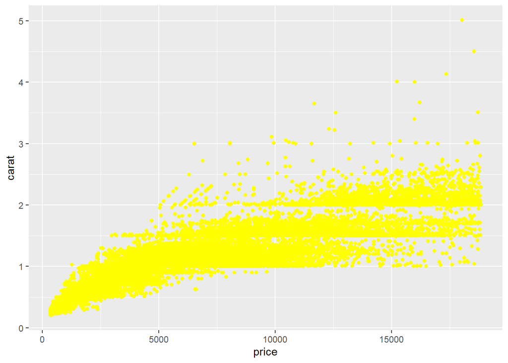

```r
ggplot(diamonds, aes(x=price, y=carat)) + geom_point(color="yellow")
```

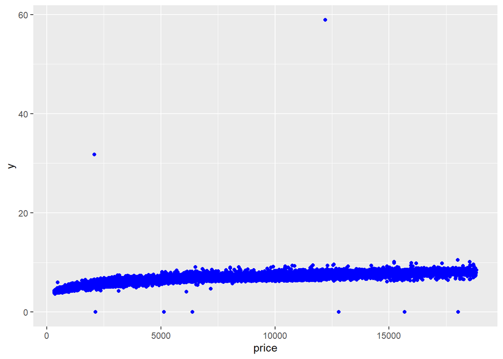

```r
ggplot(diamonds, aes(x=price, y=y)) + geom_point(color="blue")
```

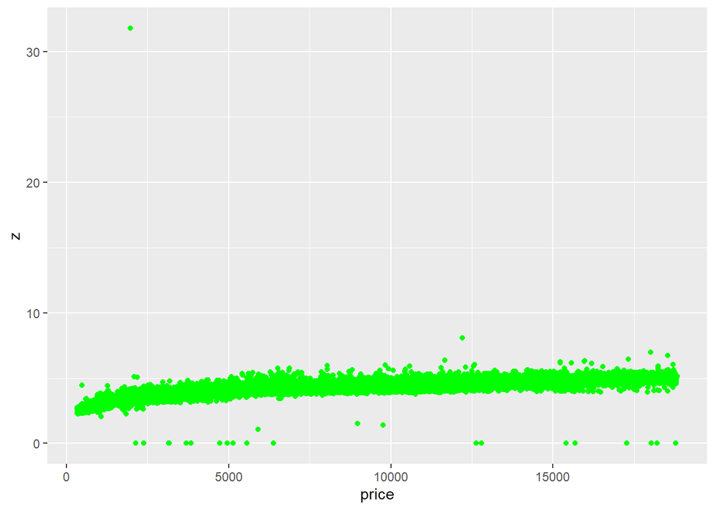

```r
ggplot(diamonds, aes(x=price, y=z)) + geom_point(color="green")
```

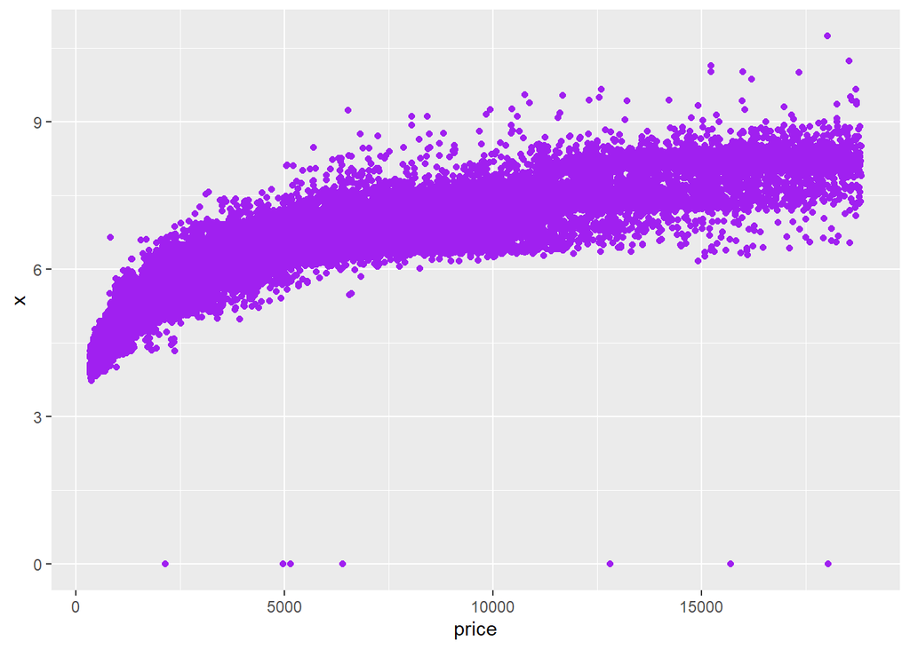

```r
ggplot(diamonds, aes(x=price, y=x)) + geom_point(color="purple")
```

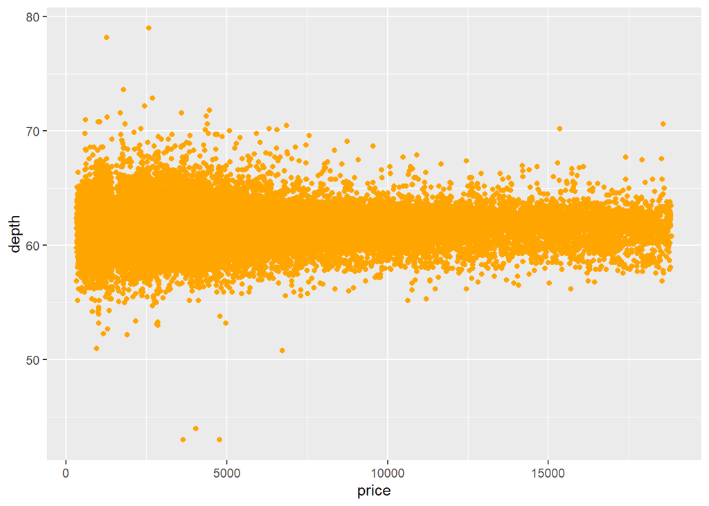

```r
ggplot(diamonds, aes(x=price, y=depth)) + geom_point(color="orange")
```

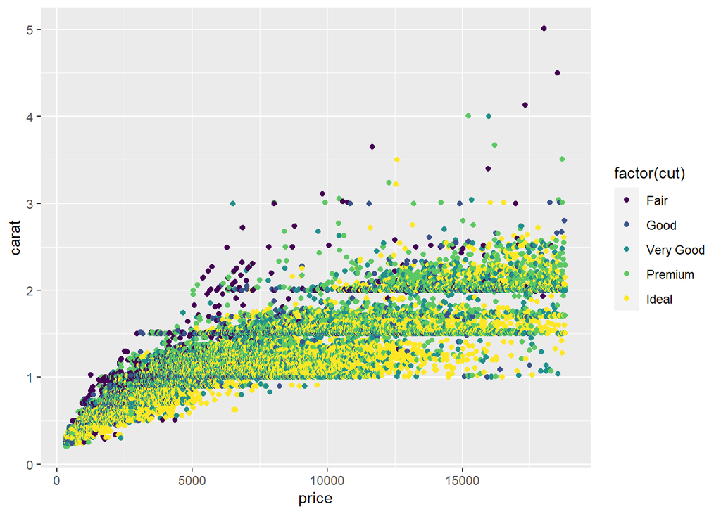

```r
#preço x peso x corte
ggplot (diamonds, aes (x = price, y = carat)) + geom_point (aes (color = factor (cut)))
```

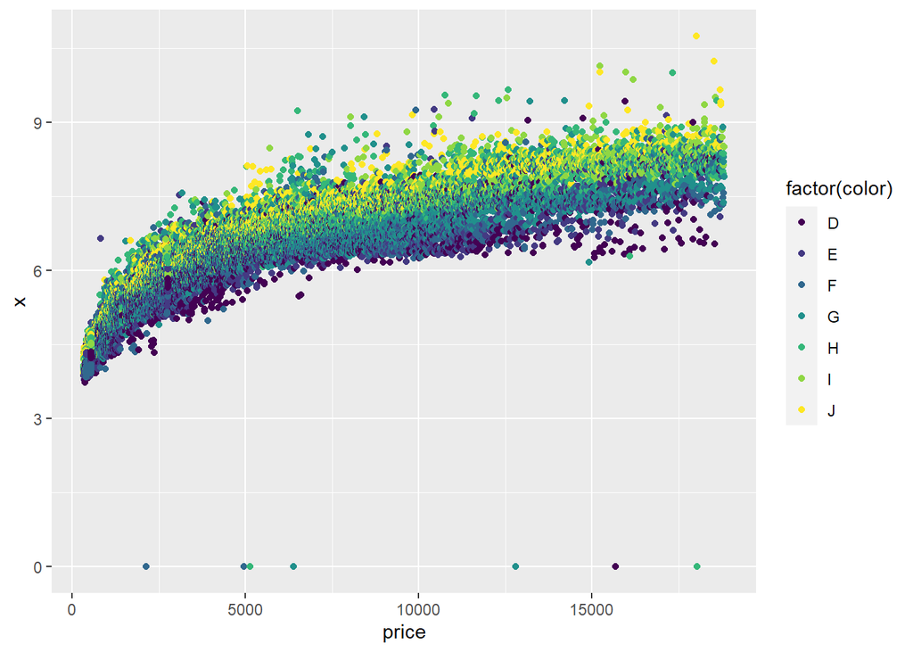

```r
#preço x comprimento x cor
ggplot (diamonds, aes (x = price, y = x)) + geom_point (aes (color = factor (color)))
```

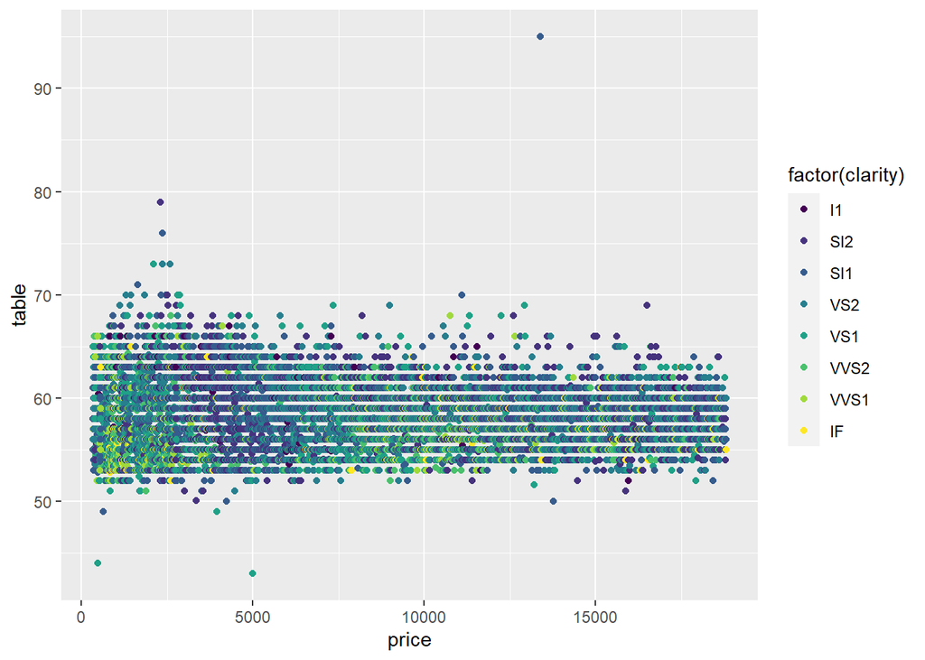

```r
#preço x largura x "transparencia ou claridade"
ggplot (diamonds, aes (x = price, y = table)) + geom_point (aes (color = factor (clarity)))
```